# Level 1 Data Skills asssignment 3

In this assignment you’re going to apply the skills you have developed from the data skills book to a new dataset. Almost everything you will be asked to do is something you have done before, just using a different dataset. You don’t need to start from scratch, you can adapt code you have you used previously to use the new data and variables names. You are permitted to use AI to complete this assessment.

## The datasets

`demographics.csv` this is a dataset of demographic data. It contains data on the participants’ age, gender (male, female, nonbinary), language (1 = English first language English, 2 = English second language), and employment (number of hours worked per week). There is also `user_id` which is an ID number that uniquely identifies the participant.

`self_efficacy.csv` contains the scores from a self-efficacy for learning questionnaire (the full questionnaire can be found here https://files.eric.ed.gov/fulltext/ED338122.pdf if you’d like more detail). Self-efficacy is a self-appraisal of one’s ability to master a task.

Self-efficacy includes judgements about one’s ability to accomplish a task as well as one’s confidence in one’s skills to perform that task. There were eight questions, and participants responded on a Likert scale from 1 (not true of me at all) to 7 (very true of me). An example of a question is “I’m certain I can master the skills being taught in this class”.

The dataset contains the responses to each individual question (`self_efficacy_1:self_efficacy_8`) as well as a column with each participant’s mean self-efficacy score (`self_efficacy`).There is also `user_id` which is an ID number that uniquely identifies the participant and matches the `user_id` found in `demographics`.

There are 3239 participants and this is all real data (from previous UofG psychology students).

## Top tips for successfully completing this assessment

- Work as a pair during the lab
- Do not delete any backticks or any of the code at the top or bottom of the grey code chunks. Only edit the `NULL` values.
- Knit the file after each activity. If it works, you know you haven’t done anything to break the file/have provided illegal code.
- If the question asks you to reproduce a table, the column names should be spelled exactly the same (remember R is case sensitive) and they should be in the same order.
- If the question asks you to reproduce a graph, any use of colour does not have to match exactly but it must be colour-blind friendly. You should reproduce any edits that have been made to axis labels etc.

### Set-up

Run the below code to load the tidyverse, the datasets, and join them together.

```r
library(tidyverse)
demo_data <- read_csv("demographics.csv")
se_data <- read_csv("self_efficacy.csv")
full_dat <- inner_join(demo_data, se_data, by = "user_id")
```

### Activity 1

In the `question01` code chunk, write the code to reproduce the table in the instructions by selecting a subset of the variables from the full dataset and store it in an object named `analysis_data`.

```r
analysis_data <- full_dat %>%
  select(user_id,
         user_gender,
         user_age,
         language,
         employment,
         self_efficacy)
```

### Activity 2

In the `question02` code chunk, write the code to change the variable `language` to reproduce the table in the instructions and store this in a new object named `factor_data`. Use `analysis_data` as the starting dataset.

```r
factor_data <- analysis_data %>%
  mutate(language = factor(language,
                           levels = c(1,2),
                           labels = c("First language", "Second language")))
summary(factor_data)
```

```
##     user_id      user_gender           user_age                language
##  Min.   :15917   Length:3239        Min.   :18.00   First language :2568
##  1st Qu.:25813   Class :character   1st Qu.:18.00   Second language: 671
##  Median :29198   Mode  :character   Median :19.00
##  Mean   :41061                      Mean   :20.57
##  3rd Qu.:60918                      3rd Qu.:20.75
##  Max.   :64746                      Max.   :59.00
##    employment     self_efficacy
##  Min.   : 0.000   Min.   :1.000
##  1st Qu.: 0.000   1st Qu.:4.000
##  Median : 0.000   Median :4.875
##  Mean   : 5.916   Mean   :4.776
##  3rd Qu.:10.000   3rd Qu.:5.625
##  Max.   :40.000   Max.   :7.000
```

```r
str(factor_data)
```

```
## tibble [3,239 × 6] (S3: tbl_df/tbl/data.frame)
##  $ user_id      : num [1:3239] 15917 16078 18549 18932 19056 ...
##  $ user_gender  : chr [1:3239] "female" "female" "male" "female" ...
##  $ user_age     : num [1:3239] 30.2 21.6 28.9 20 21.7 23.7 20 19 18 25 ...
##  $ language     : Factor w/ 2 levels "First language",..: 1 1 1 2 2 2 1 1 1 1 ...
##  $ employment   : num [1:3239] 0 2 20 0 0 0 0 0 12 10 ...
##  $ self_efficacy: num [1:3239] 4.12 3.88 4 6 4.38 ...
```

### Activity 3

Now, calculate some descriptive statistics about the sample. In the `question03` code chunk, write the code to count the total number of participants to reproduce table in the instructions and store it in an object named `total_n`. Use `factor_data` as your starting dataset.

```r
total_n <- factor_data %>%
  summarise(n = n())
```

### Activity 4

Next, calculate sample size by gender. In the `question04` code chunk, write the code to reproduce table in the instructions and store it in an object named `gender_n`. Use `factor_data` as your starting dataset.

```r
gender_n <- factor_data %>%
  count(user_gender)
```

### Activity 5

Then, calculate stats for the age range of the participants. In the `question05` code chunk, write the code to reproduce the table in the instructions and store it in an object named `age_stats`. Use `factor_data` as your starting dataset.

```r
age_stats <- factor_data %>%
  summarise(mean_age = mean(user_age),
            sd_age = sd(user_age))
```

### Activity 7

Now we’ll visualise the gender differences. Write the code to reproduce the plot in the instructions in the `question07` code chunk:

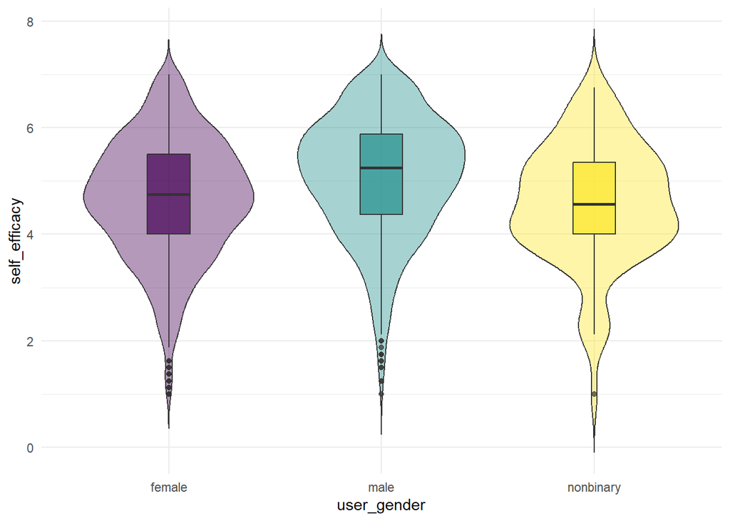

```r
ggplot(full_dat, aes(x = user_gender,
                         y = self_efficacy,
                         fill = user_gender)) +
  geom_violin(show.legend = FALSE,
              trim = FALSE,
              alpha = .4,
              width = 0.8) +
  geom_boxplot(show.legend = FALSE,
               width = .2,
               alpha = .7) +
  theme_minimal() +
  scale_fill_viridis_d("D")
```

### Activity 9

Now visualise the difference between language groups. Write the code to reproduce the plot n the instructions in the `question09` code chunk.

- Hint 1: `binwidth = .5`
- Hint 2: `scales = "free_y"`

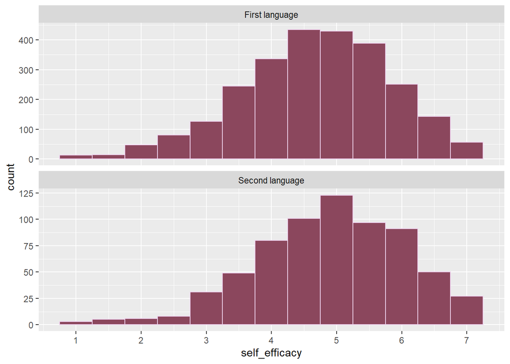

```r
ggplot(data = factor_data, aes(x = self_efficacy)) +
  geom_histogram(binwidth = .5,
                 fill = "palevioletred4",
                 colour = "thistle2") +
  facet_wrap(~language, nrow = 3, scales = "free_y") +
  scale_x_continuous(breaks = seq(1:9))
```

### Activity 10

We haven’t shown you how to do the final two questions explicitly in the book. It’s up to you to problem solve and use the help documentation, Google, or AI to get to the answer.

In the `question10` code chunk, write the code to reproduce the table in the instructions. `high_employment` equals `TRUE` if the participant works **more** than 16 hours per week (the recommended limit for those in full-time study), and `FALSE` if they work 16 hours or less. Store this in `mutate_data`. Use `factor_data` as the starting dataset.

```r
mutate_data <- factor_data %>%
  mutate(high_employment = employment > 16)
```

## Activity 11

Finally, write the code to reproduce the plot in the instructions in the `question11` code chunk. Use `mutate_data` as your starting dataset.

- Hint: `title` and `subtitle`

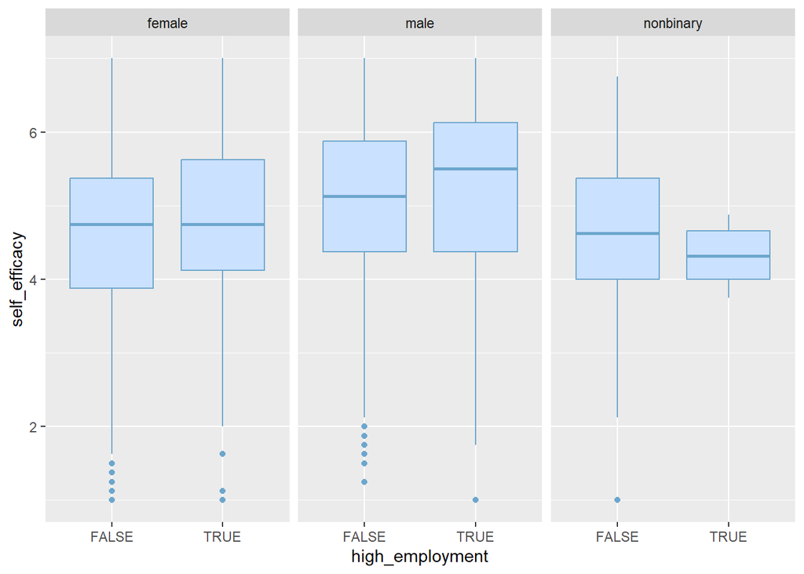

```r
ggplot(mutate_data, aes(x = high_employment,
                        y = self_efficacy,
                        fill = high_employment)) +
  geom_boxplot(colour = "skyblue3", fill = "lightsteelblue1") +
  facet_wrap(~user_gender) +
  guides(fill = "none")
```

### Write-up

If you’ve managed this all correctly, copy and paste the inline code from the instructions to the white space below this sentence and you should get the same values as in the instructions.

**copy the inline code below this line**

In total there were 3239 participants (female = 2181, male = 968, non-binary = 90, mean age = 20.57 (SD = 5.07)).

Second language English speakers reported higher self-efficacy (median = 5) than first language English speakers (median = 4.75).

#### Well done!

Once you’ve finished, upload your Rmd to Moodle. All members of your group must upload the Rmd file individually to get the mark for participation for this assessment.

This is the final R assignment for Psych 1A - take a moment to recognise how much you’ve learned and how much you’re able to do. You can now do basic data wrangling and visualisation and you can do it in an open and reproducible way - you don’t know any different because you’ve never been taught anything else but trust us, that’s amazing and it makes you some of the most competitive and highly skilled psychology students in the UK.